# Unsupervised Learning: Trade&Ahead

## Dimensionality Reduction using PCA for visualization

```python
# Let's use PCA to reduce the data to two dimensions and visualize it to see how well-separated the clusters are.
# importing library
from sklearn.decomposition import PCA

# setting the number of components to 2
pca = PCA(n_components=2)

# transforming data and storing results in a dataframe
X_reduced_pca = pca.fit_transform(subset_scaled_df)
reduced_df_pca = pd.DataFrame(
    data=X_reduced_pca, columns=["Component 1", "Component 2"]
)
```

```python
# checking the amount of variance explained
pca.explained_variance_ratio_.sum()
```

```
0.3780803776166571
```

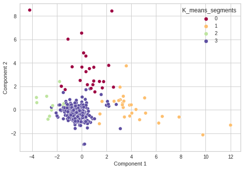

```python
sns.scatterplot(data=reduced_df_pca, x="Component 1", y="Component 2",hue=df["K_means_segments"],palette="Spectral");
```

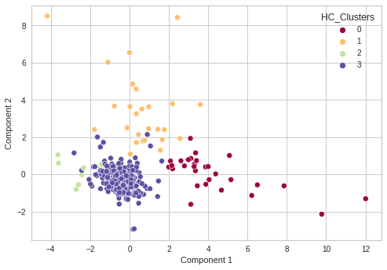

```python
sns.scatterplot(data=reduced_df_pca, x="Component 1", y="Component 2",hue=df1["HC_Clusters"],palette="Spectral");
```

## K-means vs Hierarchical Clustering

You compare several things, like:

- Which clustering technique took less time for execution?
  - Both the clustering technique took almost same minimal time.
- Which clustering technique gave you more distinct clusters, or are they the same?
  - Both algorithms give similar cluster, with 1 major cluster with almost same number of stocks.
- How many observations are there in the similar clusters of both algorithms?
  - There is 1 major cluster containing max of stocks and remaining clusters covers outliers containing 9-29 stocks.
- How many clusters are obtained as the appropriate number of clusters from both algorithms?
  - Both the algorithms are giving us 4 clusters.
- You can also mention any differences or similarities you obtained in the cluster profiles from both the clustering techniques.
  - As mentioned before, there is `no difference in number of clusters with both the algorithm.
  - Obtained clusters are giving very similar results including similar companies and GICS Sectors.

## Actionable Insights and Recommendations

- As we can see from EDA,
  - As a stock becomes more volatile, its price is likely to be dropping. Also a company generates higher net income, its price is likely less volatile. **One cluster with 25+ securities, mostly belongs to Energy sector falls under this category, making it very aggressive investment plan.**
  - Net income is positively related to earnings per share and estimated shares outstanding. Also Cluster with high net income have the lowest volatility and P/E Ratio. **One cluster with 10 or so companies, mostly belongs to Financials, Telecommunications Services sector falls under this category, making it moderately aggressive and high performing investment plan.**
  - Current price is positively related to Earning Per Share, P/E Ratio. **One Cluster with 25+ securities, mostly belongs to Health Care and Consumer Discretionary sector falls under this category, making it risky cluster, very aggressive and high performing invetsment.**
  - **Last cluster, which is a major cluster with 270+ securities, mostly belongs to Industrials and Financials sectors. This cluster is seems to be safe cluster with moderate values.**
- Trade&Ahead should first identify the financial goals, risk tolerance, and investment behaviors of their clilents, then recommend a cluster as a potential portfolio of stocks which will fit these needs.
- Alternatively, Trade&Ahead could use these clusters as an starting point for further financial statement analysis. They should further analyse individual stock that do not fit the particular cluster.
- Considering volatility of stock market, this analysis should be done dynamically on frequent basis.